# Заклинания Shadowsocks

Настройка за полторы команды.

2023.07.11

# Shadowsocks

[Shadowsocks](https://shadowsocks.org/) — протокол прокси с шифрованием.

> Shadowsocks is a secure split proxy loosely based on SOCKS5.

*Пара ремарок*:

- *Зачем он мне?* Чтобы ходить на запрещё… решать проблемы с подключением к некоторым веб-серверам.
- *Почему не полноценный VPN?* Потому что OpenVPN и Wireguard меня разочаровали. OpenVPN я не смог поддерживать, а Wireguard развалился от бит-рота.
- *Это безопасно?* Я не эксперт в криптографии, я не знаю. В [поддерживаемых алгоритмах шифрования](https://shadowsocks.org/doc/aead.html) есть слова AES и CHACHA, для моих целей этого более чем достаточно.

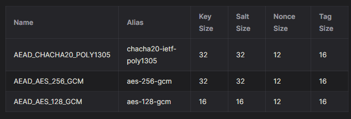

# Деплой

Деплоим на обычный линукс-сервер с докером:

```bash
echo $(ваш-любимый-генератор-паролей) > .shadowsocks-password
docker run -e "PASSWORD=$(cat .shadowsocks-pass)" --name shadowsocks --restart=unless-stopped -p 8388:8388 -p 8388:8388/udp -d shadowsocks/shadowsocks-libev
```

Получаем сервер Shadowsocks на порту `8388` с указанным паролем. Все остальные настройки по умолчанию.

- По умолчанию используется алгоритм `aes-256-gcm`.
- Хранить и указывать пароль плейн-текстом - плохо. Не делайте так в домашних условиях.
  - Мне можно, потому что я панк.
- Не забываем обмазаться фаерволом и пробить в нём дырку под соответствующий порт.
- Подробная инфа в [репозитории образа](https://github.com/shadowsocks/shadowsocks-libev/blob/master/docker/alpine/README.md).

# Клиенты

Сервер shadowsocks есть, теперь нужен клиент.

## Android

- Устанавливаем красивый и функцинальный [клиент с gh](https://github.com/shadowsocks/shadowsocks-android) или берём релиз из стора.
- Запускаем, добавляем и настраиваем новое подключение, указав IP нашего сервера, пароль, и метод шифрования.
  - По дефолту в докере выбирается `aes-256-gcm`, а в клиенте - какой-то другой. Если алгоритмы разойдутся, клиент не покажет ошибок, но соединения не будет.
  - Для диагностики проблем смотрим логи сервера: `docker logs shadowsocks`.

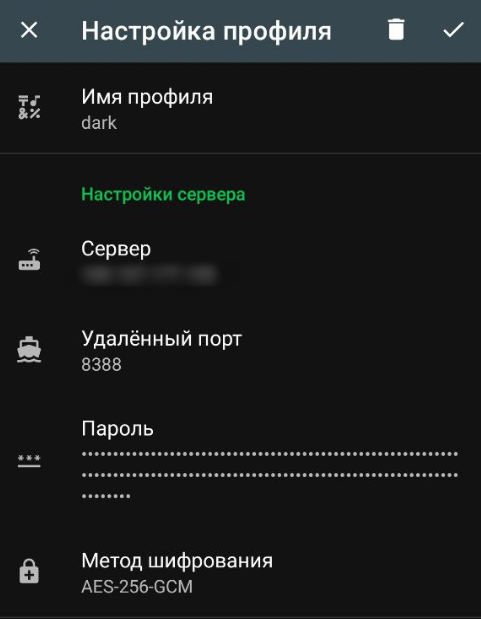

Shadowsocks android settings

- Shadowsocks на андроиде рабоает как VPN. Есть гениальная фича с выборочным VPN для приложений.

[figure not shown]

Shadowsocks android selective VPN

## Windows

- Устанавливаем менее красивый, шарповый, но всё ещё функциональный [клиент](https://github.com/shadowsocks/shadowsocks-windows).
- Повторяем те же настройи, что и на андроиде.

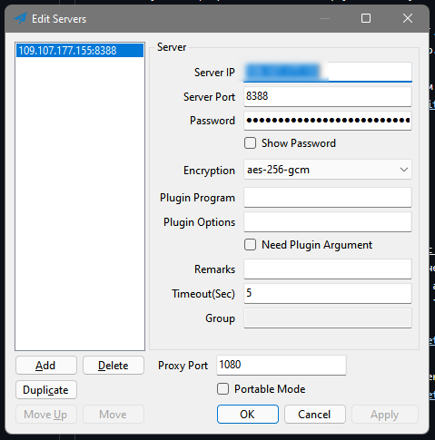

Shadowsocks windows settings

- На винде shadowsocks не пытается изображать из себя VPN, и поднимает локальный SOCKS5-прокси на указанном порту.
  - Используем стандартные системные настройки, [плагины для браузера](https://getfoxyproxy.org/) и настройки приложений.

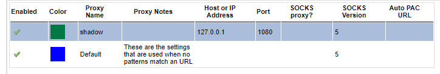

FoxyProxy shadowsocks

*(!)* Очень хорошо, что локальный SOCKS5 работает без пароля, потому что [Chrome не умеет в SOCKS с авторизацией](https://bugs.chromium.org/p/chromium/issues/detail?id=256785).

## Linux

- Вы знаете что делать.
  - [GUI-шный клиент архивирован](https://github.com/shadowsocks/shadowsocks-qt5).
  - [Оригинальная реализация](https://github.com/shadowsocks/shadowsocks) выглядит потёртой, но попробуйте попереключать веточки репозитория.
  - [Есть актуальная реализация на Ссях](https://github.com/shadowsocks/shadowsocks-libev#run-as-client), на котором и строится докер.

## Ссылки

- [Shadowsocks](https://shadowsocks.org/)
- [Shadowsocks AEAD ciphers](https://shadowsocks.org/doc/aead.html)
- [shadowsocks-libev docker readme](https://github.com/shadowsocks/shadowsocks-libev/blob/master/docker/alpine/README.md)
- shadowsocks-android
- shadowsocks-windows
- shadowsocks-qt5
- [shadowsocks original implementation](https://github.com/shadowsocks/shadowsocks)
- [shadowsocks-livev](https://github.com/shadowsocks/shadowsocks-libev#run-as-client)
- [FoxyProxy](https://getfoxyproxy.org/)
- [Chromium bugs: Issue 256785: SOCKS5 authentication support](https://bugs.chromium.org/p/chromium/issues/detail?id=256785)